# STAT/MATH 495: Problem Set 07

Brendan Seto

2017-10-24

# Build binary classifier

Outcome variable: whether or not someone experienced 90 days past due delinquency or worse in the last 2 years

Build the binary classifier based on a single predictor variable: `DebtRatio`, `age`, or `MonthlyIncome`. Justify this choice.

**Data Exploration: Is there a Difference in our three predictors?**

```r
trainM <- train %>% sample_frac(0.8)
testM <- anti_join(train, trainM, by = "Id")

df <- train %>% select(Id, SeriousDlqin2yrs, MonthlyIncome, age, DebtRatio) %>%
  gather(var, value, MonthlyIncome:DebtRatio) %>%
  mutate(SeriousDlqin2yrs = ifelse(SeriousDlqin2yrs == 1, "Yes","No"))

# Age
a <- ggplot(filter(df, var == "age")) +
  geom_boxplot(aes(x=SeriousDlqin2yrs, y=value, color = SeriousDlqin2yrs)) +
  labs(x="Serious Delinquency In Past 2 Years", y="Age")+
  guides(color = FALSE)+
  labs(title="Age")


# Monthly Income
MI <- ggplot(filter(df, var == "MonthlyIncome")) +
  geom_boxplot(aes(x=SeriousDlqin2yrs, y=log(value), color = SeriousDlqin2yrs)) +
  labs(x="Serious Delinquency In Past 2 Years", y="Monthly Income")+
  guides(color = FALSE)+
  labs(title="Monthly Income")

# Debt Ratio
DR <- ggplot(filter(df, var == "DebtRatio")) +
  geom_boxplot(aes(x=SeriousDlqin2yrs, y=log(value), color = SeriousDlqin2yrs)) +
  labs(x="Serious Delinquency In Past 2 Years", y="Debt Ratio")+
  guides(color = FALSE)+
  labs(title="Debt Ratio")
```

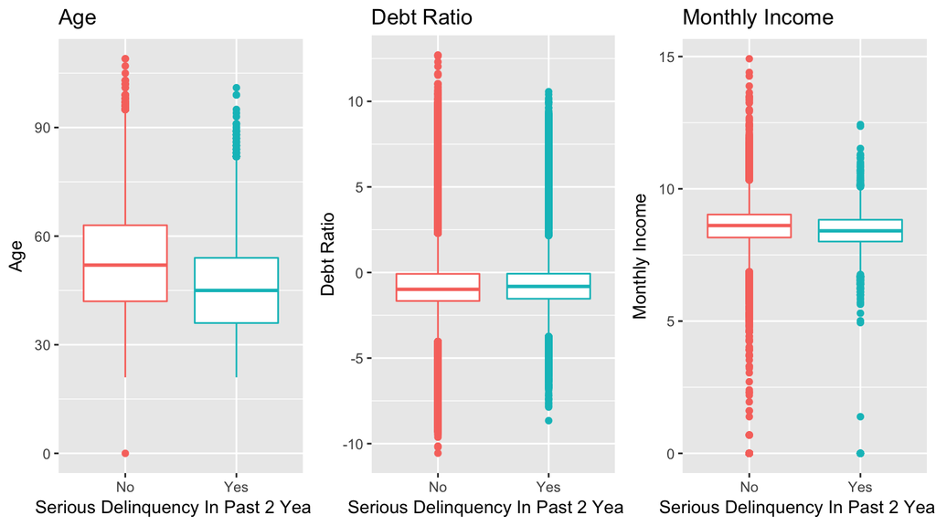

```r
grid.arrange(a,DR,MI, ncol = 3)
```

I’m choosing to use age. Of all the variables, it seems to have the largest seperation between outcomes. It also is much less skewed (we had to take the log of Debt Ratio and Monthly Income) and has far fewer outliers. Thus, we believe there will be more seperation and fewer misclassifications if we use this variable.

# ROC curve

Based on the ultimate classifier you choose, plot a corresponding ROC curve.

```r
# First make the model
m_age <- glm(SeriousDlqin2yrs~age, data=trainM, family = "binomial")
predictions_a <- m_age %>%
  broom::augment(newdata=testM) %>%
  mutate(p_hat = 1/(1 + exp(-.fitted)))

# This bit of code computes the ROC curve
pred <- prediction(predictions = predictions_a$p_hat, labels = predictions_a$SeriousDlqin2yrs)
perf <- performance(pred, "tpr","fpr")

# This bit of code computes the Area Under the Curve
auc <- as.numeric(performance(pred,"auc")@y.values)
```

The AUC of this model is 0.6359.

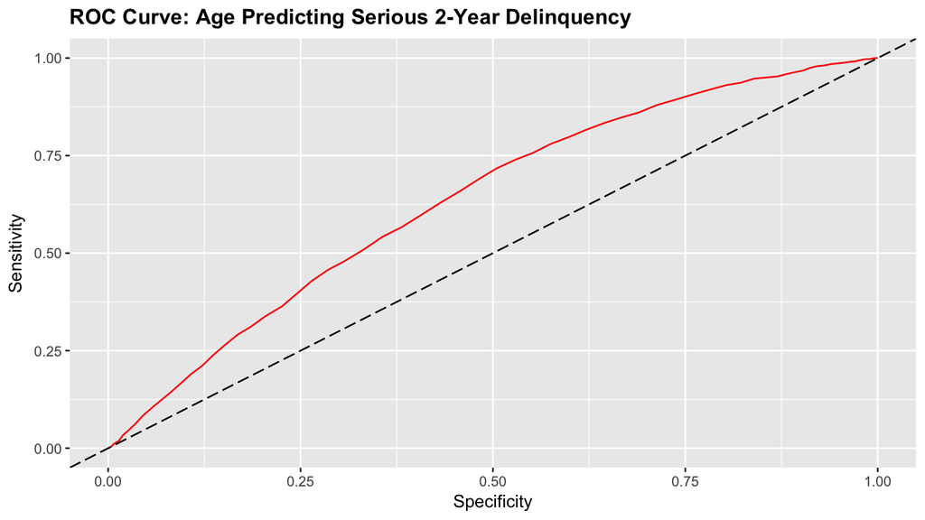

```r
ggplot(NULL, aes(unlist(perf@x.values), unlist(perf@y.values)))+geom_line(color = "red")+
  geom_abline(slope=1, linetype = "longdash")+
  labs(list(title = "ROC Curve: Age Predicting Serious 2-Year Delinquency", x = "Specificity", y = "Sensitivity"))+
  theme(plot.title = element_text(face = "bold"))
```

# ROC curve for random guessing

Instead of using any predictor information as you did above, switch your predictions to random guesses and plot the resulting ROC curve.

```r
pred1 <- prediction(predictions = ifelse(runif(30000)>0.5, 1,0), labels = predictions_a$SeriousDlqin2yrs)
perf1 <- performance(pred1, "tpr","fpr")

# This bit of code computes the Area Under the Curve
auc1 <- as.numeric(performance(pred1,"auc")@y.values)
```

The AUC of this model is 0.5089.

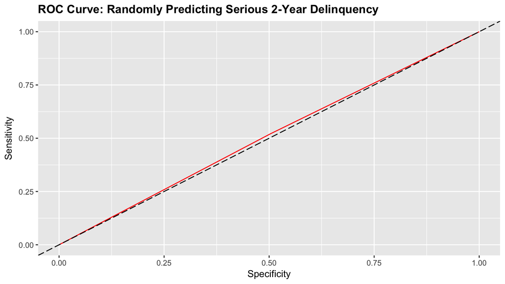

```r
ggplot(NULL, aes(unlist(perf1@x.values), unlist(perf1@y.values)))+geom_line(color = "red")+
  geom_abline(slope=1, linetype = "longdash")+
  labs(list(title = "ROC Curve: Randomly Predicting Serious 2-Year Delinquency", x = "Specificity", y = "Sensitivity"))+
  theme(plot.title = element_text(face = "bold"))
```

We can see that the curve does not deviate very much at all from y=x.

# Submission

```r
test[is.na(test$age),"Age"] <- median(test$age, na.rm=TRUE)

Submission <- m_age %>%
  broom::augment(newdata=test) %>%
  mutate(Probability = 1/(1 + exp(-.fitted))) %>%
  select(Id, Probability)

write.csv(Submission, "sub.csv")
```

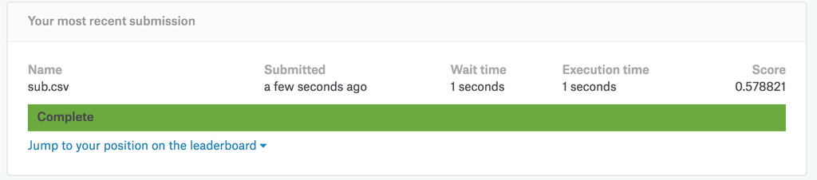

My Kaggle Submission